# Skąd rząd bierze pieniądze na 500 plus?

Tomasz Radzikowski

3 marca 2019

## Artykuł źródłowy

https://bezprawnik.pl/skad-sie-biora-pieniadze-na-500-plus/

## Komentarz do poprawek:

Na warsztat wziąłem pracę Kolegi Olafa Skrabacza, który zaprezentował dane na temat świadomości obywateli polskich skąd pochodzą pieniądze na świadczenia socjalne (w tym przypadku program 500+)

Zaprezentowany przez Kolegę sposób przedstawienia danych nie był w żaden sposób przekłamany, ale uważam, że informacje na nim zawarte można przekazać w lepszy sposób.

Moje modyfikacje sprowadziły się do usunięcia fasetów, które co prawda pozwalały porównywać ile procent wyborców danej partii opowiada się za konkretną odpowiedzią, ale “gubiły” informacje całościowe, tj. jak rozkładają się poglądy wyborców każdej partii na każdą z zaproponowanych przez ankieterów opcji. Dzięki mojej modyfikacji można wnioskować o ogólnym podejściu wyborców danego ugrupowania politycznego do wizji gospodarki. Na przykład, mimo że pogląd “podatki, które ja płacę” jest wysoko notowany dla każdego ugrupowania, to już opcja “pieniądze rządowe” jest wybierana głównie przez wyborców PiSu, co może być odbiciem ich poparcia dla idei silnego, quasi socjalistycznego państwa, które ma pieczę nad wszystkim i wszystkimi. Prowadząc tę argumentację na temat przedstawienia danych na jednym wyrkesie dalej, widać, że wyborcy PO mają przekonanie, iż pieniądze na program 500+ pochodzą z podatków osób prywatnych. Pozostałe opcje w ankiecie zdobyły znacznie mniejszą popularność. To pozwala wysnuć wniosek o wolnorynkowych poglądach tychże wyborców i przeświadczeniu, że żadne świadczenie nie jest darmowe, lecz płacą za nie obywatele. Tak samo analiza wszystkich odpowiedzi na jednym wykresie pozwala odkryć niepokojący fakt, iż wyborcy partii Kukiz15 są mocno podzieleni i prawie połowa z nich nie ma nawet przekonań i przemyśleń, co do tego, skąd biorą się pieniądze publiczne.

## Dane

```r
procenty <- c(29,20,25,11,0,15, 37,13,6,3,0,41,
              55,26,5,9,1,4, 39, 31, 6, 1, 5, 18)
zrodla <- c("Podatki które ja płacę", "Podatki które płacą inni", "Pieniądze rządowe","Podatki płacone przez firmy", "Inne", "Nie wiem")
partie <- c("PiS", "Kukiz15", "PO", "Nowoczesna")
df <- tibble(procenty=procenty, zrodla=factor(rep(zrodla, 4), levels=zrodla),
             partie=rep(partie, each=6))
```

## Wykres oryginalny

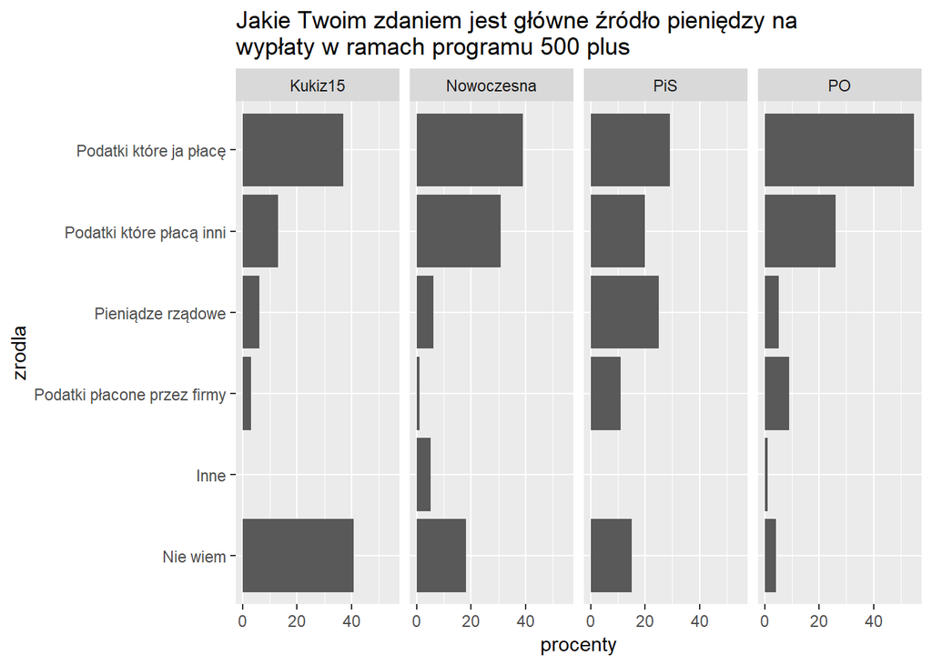

## Wykres poprawiony

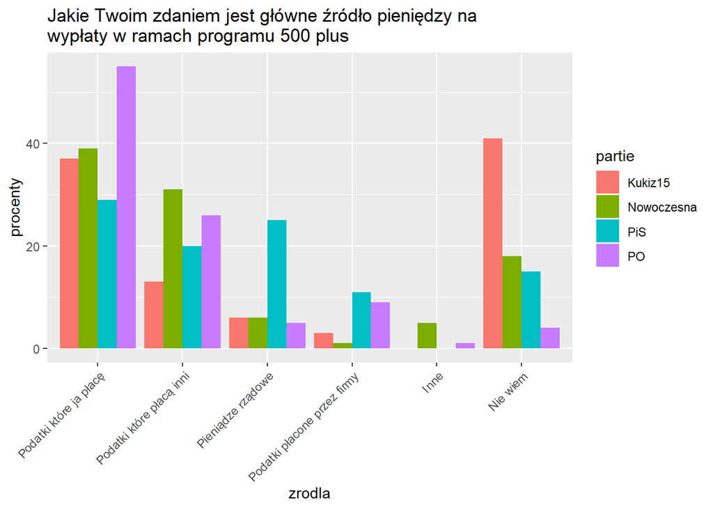